# Project 1

Chenyi Shirley He (s2279930)

# 1 Exponential likelihood regression model

## 1.1 Log-likelihood function and score function

From the likelihood function of this exponential distribution

$$L(\lambda) = \prod^{n}_{i=1}\lambda_i e^{-\lambda_i y_i},$$

we can write the log-likelihood function of $\lambda_i$ as

$$\ell(\lambda) = \sum^{n}_{i=1} (log(\lambda_i) - \lambda_i y_i),$$

and by re-parametration of $\lambda_i = e^{\beta_0 + \beta_1 x_i}$, we have

$$\begin{align}
\ell(\beta_0, \beta_1)
&= \sum_{i=1}^{n}
\left[
\log\left(e^{\beta_0+\beta_1 x_i}\right)
- y_i e^{\beta_0+\beta_1 x_i}
\right] \\
&= \sum_{i=1}^{n}
\left[
(\beta_0 + \beta_1 x_i)
- y_i e^{\beta_0+\beta_1 x_i}
\right]
\end{align}$$

Therefore, the score function could be derived by taking derivative of $\ell(\beta_0, \beta_1)$ with respect to $\beta_0, \beta_1$, respectively:

$$\frac{\partial \ell}{\partial \beta_0} = \sum^{n}_{i=1} [1 - y_i
e^{\beta_0 + \beta_1 x_i}],$$

$$\frac{\partial \ell}{\partial \beta_1} = \sum^{n}_{i=1} [x_i - y_i x_i
e^{\beta_0 + \beta_1 x_i}].$$

Since at the maximum likelihood, we have both derivatives zero, i.e., $\frac{\partial \ell}{\partial \beta_0} = \frac{\partial \ell}{\partial \beta_1} = 0$, by solving the first score function

$$\frac{\partial \ell}{\partial \beta_0} = \sum^{n}_{i=1} [1 - y_i
e^{\beta_0 + \beta_1 x_i}] = \sum^{n}_{i=1} 1 - \sum^{n}_{i=1} y_i
e^{\beta_0 + \beta_1 x_i} = 0$$

$$\Leftrightarrow n - e^{\beta_0} \sum^{n}_{i=1} y_i e^{\beta_1 x_i} = 0
\Leftrightarrow e^{\beta_0} = \frac{n}{\sum^{n}_{i=1} y_i e^{\beta_1
x_i}},$$

we obtained the closed-form expression for $\beta_0$ as

$$\beta_0(\beta_1) = log(n) - log \Bigl(\sum^{n}_{i=1} y_i e^{\beta_1
x_i}\Bigr),$$

which is a function of $\beta_1$.

This implies that $\beta_0$ is dependent of $\beta_1$, and it’s sufficient to only optimise $\beta_1$ in the optimisation problem, which, therefore, reduces the problem to one dimension.

## 1.2 Fit the regression by MLE

### 1.2.1 Setup with dataset

```r
# Load the dataset
data <- read.csv("expdata.csv")
# Inspect the variables
y <- data$y
x <- data$x
```

### 1.2.2 Compute the estimates, Hessian, and standard error

The exponential regression model was fitted using maximum likelihood estimation.

```r
# Fit the exponential regression model
fit <- fit_expreg(y, x)
fit
```

```
## $par_hat
## [1] 0.6498663 0.5453474
##
## $hessian
##          [,1]      [,2]
## [1,] 300.0132 149.89900
## [2,] 149.8990  97.92409
##
## $se
## [1] 0.1190537 0.2083859
```

And from the results above, the estimated parameters are

$$\hat{\beta}_0 = 0.6499 \quad (\hat{\text{se}}(\hat{\beta}_0) = 0.1191),$$

$$\hat{\beta}_1 = 0.5453 \quad (\hat{\text{se}}(\hat{\beta}_1) = 0.2084).$$

### 1.2.3 Plot the log-likelihood as a function of $\beta_1$

To plot the log-likelihood, we reduce it to 1D by representing them in terms of $\beta_1$ only first.

```r
beta0_hat <- function(beta1, y, x) {
  log(length(y)) - log(sum(y * exp(beta1 * x)))
}

loglik_1d <- function(beta1, y, x) {
  beta0 <- beta0_hat(beta1, y, x)
  beta1 <- beta1
  lambda <- exp(beta0 + beta1 * x)
  sum(log(lambda) - lambda * y)
}
```

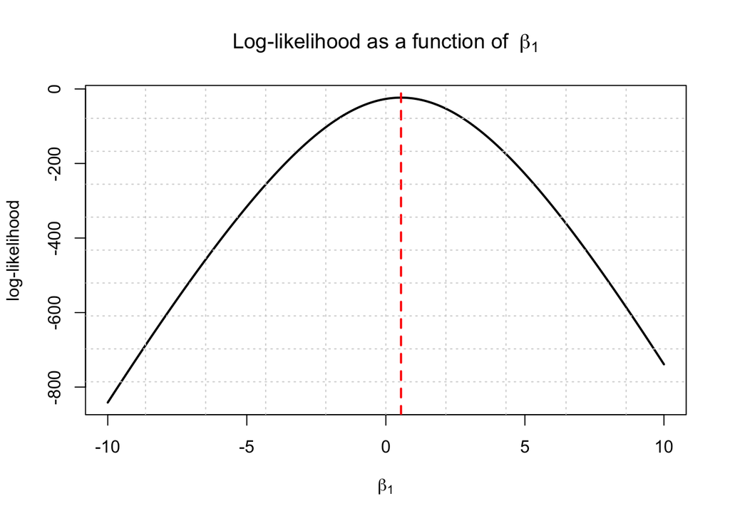

The 1D log-likelihood is a smooth, concave curve with a clear maximum. This suggests that there is a unique maximum likelihood estimate for $\beta_1$. And as $\beta_1$ moves away from this value, the log-likelihood decreases, showing that the estimate is well-defined and supported by the data.

## 1.3 MLE and Wald confidence intervals

Using the inverse Hessian from the optimisation, we obtained the MLEs and 95% Wald confidence intervals for $(\beta_0,\beta_1)$. For the transformed quantities $e^{\beta_1}$ (hazard ratio) and $e^{-\beta_1}$ (mean waiting time multiplier), the delta method gives
$$\mathrm{se}\!\left(e^{\beta_1}\right) \approx
e^{\hat\beta_1}\,\mathrm{se}(\hat\beta_1),
\qquad
\mathrm{se}\!\left(e^{-\beta_1}\right) \approx
e^{-\hat\beta_1}\,\mathrm{se}(\hat\beta_1),$$

```r
# Compute the MLE and 95% Wald confidence intervals for the regression coefficients (beta0, beta1)
CI <- CI(y, x, alpha = 0.05)

# Compute the MLE and 95% Wald confidence intervals for the regression coefficients exp(beta1)
alpha <- 0.05
z <- qnorm(1 - alpha/2)

beta1_hat <- CI["beta1", "hat"]
se_beta1  <- CI["beta1", "se"]
lo_beta1  <- CI["beta1", "lo"]
hi_beta1  <- CI["beta1", "hi"]

CI_exp_beta1 <- data.frame(
  hat = exp(beta1_hat),
  lo  = exp(lo_beta1),
  hi  = exp(hi_beta1),
  se  = exp(beta1_hat) * se_beta1,   # delta method
  row.names = "exp(beta1)"
)
# Compute the MLE and 95% Wald confidence intervals for the mean waiting time multiplier exp(-beta1)
CI_exp_neg_beta1 <- data.frame(
  hat = exp(-beta1_hat),
  lo  = exp(-hi_beta1),
  hi  = exp(-lo_beta1),
  se  = exp(-beta1_hat) * se_beta1,  # delta method se
  row.names = "exp(-beta1)"
)

# Show all results in one table
final_table <- rbind(
  "$\\beta_0$" = CI["beta0", c("lo","hat","hi","se")],
  "$\\beta_1$" = CI["beta1", c("lo","hat","hi","se")],
  "$e^{\\beta_1}$"  = CI_exp_beta1[, c("lo","hat","hi","se")],
  "$e^{-\\beta_1}$" = CI_exp_neg_beta1[, c("lo","hat","hi","se")]
)
```

and the confidence intervals are reported in the table:

| param | lo | hat | hi | se |
| --- | --- | --- | --- | --- |
| $\beta_0$ | 0.4165 | 0.6499 | 0.8832 | 0.1191 |
| $\beta_1$ | 0.1369 | 0.5453 | 0.9538 | 0.2084 |
| $e^{\beta_1}$ | 1.1467 | 1.7252 | 2.5955 | 0.3595 |
| $e^{-\beta_1}$ | 0.3853 | 0.5796 | 0.8720 | 0.1208 |

The estimate $\hat\beta_0 = 0.6499$ represents the baseline hazard when $x=0$. This gives a baseline hazard of $e^{0.6499} \approx 1.92$, which is the hazard rate in the absence of the covariate effect.

The estimate $\hat\beta_1 = 0.5453$ is positive, showing that higher values of $x$ are associated with higher hazard. The hazard ratio $e^{\hat\beta_1} = 1.7252$ means that increasing $x$ by one unit multiplies the hazard by about 1.73. The confidence interval (1.1467, 2.5955) does not include 1, suggesting that this effect is supported by the data.

Similarly, the multiplier for the mean waiting time is $e^{-\hat\beta_1} = 0.5796$, indicating that larger values of $x$ reduce the expected waiting time, so events occur sooner.

## 1.4 Investigate the large-sample behaviour of the MLE and Wald confidence intervals

To investigate the large-sample behaviour of Wald confidence intervals, we estimate the empirical coverage probability of the 95% Wald confidence interval for $\beta_1$ by simulation.

```r
# Define the true parameters
beta0_true <- fit$par_hat[1]
beta1_true <- fit$par_hat[2]

# Define the sample sizes
n_vec <- c(5, 10, 20, 50, 100, 200, 500)
N <- 10000
alpha <- 0.05

# Compute the coverage probabilities
cov_hat <- sapply(n_vec, function(n) estimate_coverage(
  n = n,
  beta0 = beta0_true,
  beta1 = beta1_true,
  x = x,
  N = N,
  alpha = alpha,
))

# Define the function to compute the Monte Carlo standard errors
mc_se_hat <- function(cov_hat, N) {
  sqrt(cov_hat * (1 - cov_hat) / N)
}

# Compute the Monte Carlo standard errors
mcse <- sapply(cov_hat, mc_se_hat, N = N)

# Create a data frame to store the results
results <- data.frame(
  n = n_vec,
  coverage = cov_hat,
  mc_se = mcse
)
```

Since the estimate of coverage is computed from $N$ simulations, it has Monte Carlo variability. Treating each replication as a Bernoulli indicator of “covered / not covered”, an approximate Monte Carlo standard error is

$$\mathrm{MCSE}(\hat p) \approx \sqrt{\frac{\hat p(1-\hat p)}{N}}.$$
This explains small differences in estimate of coverage across different $n$ when $N$ is finite.

| n | coverage | mc_se |
| --- | --- | --- |
| 5 | 0.9257 | 0.0026 |
| 10 | 0.9413 | 0.0024 |
| 20 | 0.9490 | 0.0022 |
| 50 | 0.9495 | 0.0022 |
| 100 | 0.9514 | 0.0022 |
| 200 | 0.9486 | 0.0022 |
| 500 | 0.9494 | 0.0022 |

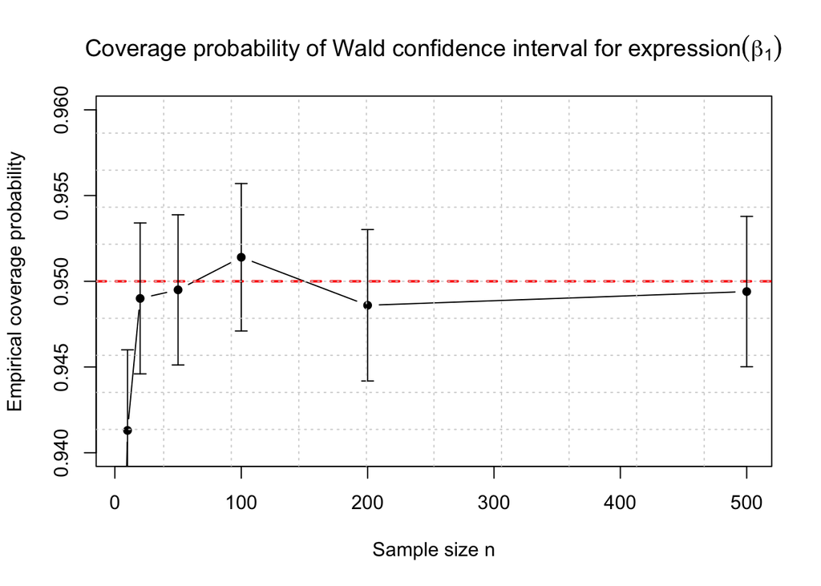

As n increases, the normal approximation underlying the Wald interval is expected to improve, and the empirical coverage should approach the nominal level of 95%. Overall, the simulation results are consistent with this theoretical behaviour.

# 2 Latent variable Poisson model

## 2.1 Monte Carlo approximation

### 2.1.1 Derive Monte Carlo estimator and check its consistency

Given the marginal probability mass function

$$p(m | \mu, \sigma) = \text{Pr}(Y=m | \mu, \sigma),$$

under the latent variable count model

$$X_i \sim N(0, \sigma^2), \, \, Y_i | X_i = x \sim
\text{Poisson}(\lambda(x)),$$

where

$$\lambda(x)=e^{\mu+x}, \, \, i = 1,\ldots, n,$$

and all the observations are independent.

By the law of total expectation, we have the explicit pmf as

$$p(Y=m|\mu, \sigma) = \mathbb{E}[\text{Pr}(Y=m|X)] =
\mathbb{E}\Bigl[\frac{e^{-e^{\mu+x}}e^{m(\mu+x)}}{m!}\Bigr] =
\mathbb{E}\Bigl[\frac{e^{-e^{\mu+x}+m(\mu+x)}}{m!}\Bigr].$$

Let $X_1, \ldots, X_n \overset{\mathrm{iid}}{\sim} N(0, \sigma^2)$. Define

$$g(x) = \frac{e^{-e^{\mu+x}+m(\mu+x)}}{m!},$$

where $p(m|\mu, \sigma) = \mathbb{E}[g(x)]$.

Therefore, the Monte Carlo estimator is

$$\hat{p}_{MC}(m|\mu, \sigma) =
\frac{1}{K}\sum^{K}_{k=1}\frac{e^{-e^{\mu+X_i}+m(\mu+X_i)}}{m!}.$$

Since $X_1, \ldots, X_K$ are i.i.d, and $0 \leq g(X) \leq 1$, we have $\mathbb{E}[|g(X)|] < \infty$.

By the Law of Large Number,

$$\hat{p}_{MC}(m|\mu, \sigma) = \frac{1}{K}\sum^{K}_{k=1} g(X_i)
\xrightarrow{K \to \infty} \mathbb{E}[g(X)] = p(m|\mu, \sigma),$$

which implies that the estimator is consistent.

### 2.1.2 Plot the Monte Carlo estimator and the true pmf

The mean of $Y$ under the latent variable model could be derived by taking expectation of $Y$ with respect to the latent variable $X$:
$$\mathbb{E}[Y] = \mathbb{E}[\mathbb{E}[Y|X]] = \mathbb{E}[\lambda(X)] =
\mathbb{E}[e^{\mu+X}] = e^{\mu} \mathbb{E}[e^{X}] = e^{\mu}
e^{\sigma^2/2} = e^{\mu + \sigma^2/2},$$
where $\mathbb{E}[e^{X}] = e^{\sigma^2/2}$ is derived using the moment generating function of $X \sim N(0, \sigma^2)$.

For $(\mu, \sigma)=(0.2, 0.8)$, this gives $\mathbb{E}[Y]=e^{0.52} \approx 1.682$, and we use this as the mean of the ordinary Poisson distribution.

```r
# Define the parameters
mu <- 0.2
sigma <- 0.8
m <- 0:20
K <- 10000

# Compute the Monte Carlo estimator
mc_result <- dlatentpois_mc(m, mu, sigma, K)

# Mean of the ordinary Poisson distribution
pois_mean <- exp(mu + sigma^2 / 2)

# Pmf of the ordinary Poisson distribution
pois_pmf <- dpois(m, lambda = pois_mean)
```

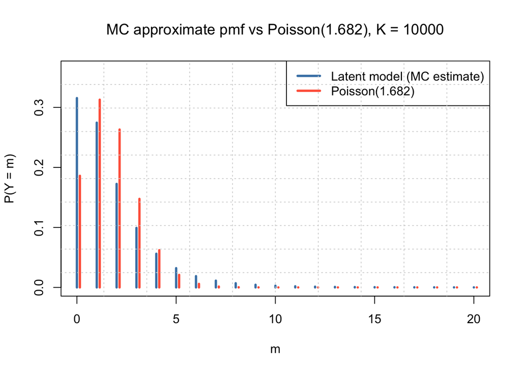

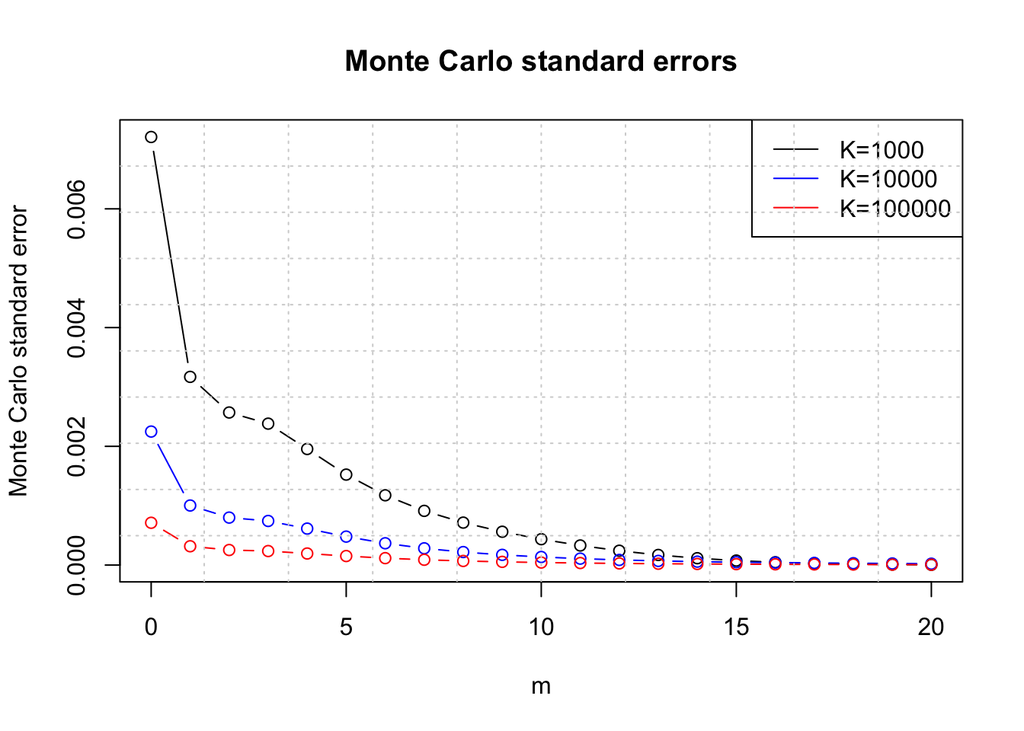

From the Monte Carlo standard error plot, the standard error decreases as K increases. This confirms that using more simulations improves the accuracy of the Monte Carlo estimator. The standard error is largest where the probability mass is highest, and becomes very small for large m where the probability is close to zero.

These results show that the Monte Carlo estimator is accurate and becomes more reliable as the number of simulations increases.

## 2.2 Importance sampling approximation

We now improve the Monte Carlo approximation using importance sampling.

### 2.2.1 Estimate the pmf for $m = 10$ and compare with the MC approximation

```r
# Define the parameters
m <- 10
mu <- 0.2
sigma <- 0.8
K <- 5000

# Compute the crude MC approximation
crude_MC <- dlatentpois_mc(m, mu, sigma, K)
crude_MC
```

```
##      m         pmf           se
## pmf 10 0.002880474 0.0001912868
```

```r
# Compute the importance sampling estimator
a <- log(10) - mu
is_result <- dlatentpois_is(m, mu, sigma, a, K)
is_result
```

```
##      m         pmf           se
## pmf 10 0.002844738 3.846775e-05
```

```r
# Compare the MC standard errors
comparison <- data.frame(
  method = c("Crude MC", "Importance Sampling"),
  estimate   = c(crude_MC$pmf, is_result$pmf),
  standard_error  = c(crude_MC$se, is_result$se)
)

knitr::kable(comparison, digits = 6)
```

| method | estimate | standard_error |
| --- | --- | --- |
| Crude MC | 0.002880 | 0.000191 |
| Importance Sampling | 0.002845 | 0.000038 |

Both methods produce very similar estimates for $P(Y=10)$, which indicates that the estimators are consistent.

However, the standard error from importance sampling is much smaller than that from crude Monte Carlo. This means importance sampling gives a more stable and reliable estimate.

This happens because importance sampling shifts the sampling distribution towards values of $X$ that contribute more to the event $Y=10$. In contrast, crude Monte Carlo samples many values that contribute very little, which increases variability. Therefore, importance sampling reduces variance and improves efficiency.

# 3 Code appendix

```r
#' Chenyi(Shirley) He, S2279930
#' Add all your function definitions to this file.
#' Each function should be documented using the same style as below.

#' Negative log-likelihood for exponential regression
#'
#' Computes the negative log-likelihood for the exponential regression model
#'   y_i ~ Exponential(rate = exp(beta0 + beta1 * x_i)).
#'
#' @param par numeric vector of length 2 containing (beta0, beta1)
#' @param y numeric vector of strictly positive responses
#' @param x numeric vector of covariates (same length as y)
#' @return numeric scalar: negative log-likelihood value
negloglik_expreg <- function(par, y, x) {

  beta0 <- par[1]
  beta1 <- par[2]

  lambda <- exp(beta0 + beta1 * x)

  return(sum(-log(lambda) + lambda * y))

}

#' Fit exponential regression by MLE
#'
#' Compute MLE for beta_0 and beta_1 using optim()
#'
#' @param y numeric vector of strictly positive responses
#' @param x numeric vector of covariates (same length as y)
#' @return list: MLE for parameters(par_hat), Hessian matrix(H_mat), standard error(se), optim
fit_expreg <- function(y, x) {

  opt <- optim(
    par = c(0,0),
    fn  = negloglik_expreg,
    y   = y,
    x   = x,
    hessian = TRUE
  )

  H_mat <- opt$hessian
  cov_mat <- solve(H_mat)
  se <- sqrt(diag(cov_mat))

  return(list(
      par_hat = opt$par,
      hessian = H_mat,
      se = se
    ))

}

#' Wald confidence intervals
#'
#' Computes the Wald confidence intervals for the parameters of the exponential regression model
#'   y_i ~ Exponential(rate = exp(beta0 + beta1 * x_i)).
#'
#' @param y numeric vector of strictly positive responses
#' @param x numeric vector of covariates (same length as y)
#' @param alpha significance level
#' @return data frame: Wald confidence intervals for parameters
CI <- function(y, x, alpha = 0.05) {
  fit <- fit_expreg(y, x)
  par_hat <- fit$par_hat
  se  <- fit$se
  z   <- qnorm(1 - alpha / 2)

  result_df <- data.frame(
    hat = par_hat,
    lo  = par_hat - z * se,
    hi  = par_hat + z * se,
    se  = se,
    row.names = c("beta0", "beta1")
  )
  return(result_df)
}

#' Investigate the large-sample behavior of Wald intervals
#'
#' The coverage probability is the probability that the true value of beta1 is within the Wald confidence interval.
#'
#' @param n sample size
#' @param beta0 true value of beta0
#' @param beta1 true value of beta1
#' @param x covariates
#' @param N number of simulations
#' @param alpha significance level
#' @param seed random seed
#' @return numeric scalar: empirical coverage probability
estimate_coverage <- function(n, beta0, beta1, x, N = 10000, alpha = 0.05, seed = NULL) {
  if (!is.null(seed)) set.seed(seed)

  coverage <- logical(N)
  z <- qnorm(1 - alpha/2)

  for (i in 1:N) {

    # resample covariates
    x_sam <- sample(x, n, replace = TRUE)

    # simulate exponential responses
    lambda <- exp(beta0 + beta1 * x_sam)
    y_sam <- rexp(n, rate = lambda)

    # fit model and compute Wald CI
    fit <- fit_expreg(y_sam, x_sam)
    beta1_hat <- fit$par_hat[2]
    se <- fit$se[2]

    lo <- beta1_hat - z * se
    hi <- beta1_hat + z * se

    # check coverage
    coverage[i] <- (beta1 >= lo) & (beta1 <= hi)
  }

  return(mean(coverage))
}

#' Monte Carlo estimator for the latent variable Poisson model
#'
#' Estimates the marginal pmf p(Y = m | mu, sigma) where
#' X ~ N(0, sigma^2),  Y | X=x ~ Poisson(exp(mu + x)).
#'
#' @param m number of trials
#' @param mu mean of the Poisson distribution
#' @param sigma standard deviation of the Poisson distribution
#' @param K number of Monte Carlo simulations
#' @return data frame with columns: m, pmf, se
dlatentpois_mc <- function(m, mu, sigma, K){

  x <- rnorm(K, mean = 0, sd = sigma)

  result <- sapply(m, function(mi) {
    g <- exp(-exp(mu + x) + mi * (mu + x)) / factorial(mi)
    c(pmf = mean(g), se = sd(g) / sqrt(K))
  })
  result <- matrix(result, nrow = 2, dimnames = list(c("pmf", "se"), NULL))

  data.frame(m = m, pmf = result["pmf", ], se = result["se", ])

}


#' Importance sampling estimator for the latent variable Poisson model
#'
#' Estimates the marginal pmf p(Y = m | mu, sigma) using importance sampling
#' with proposal distribution N(a, sigma^2), where
#' X ~ N(0, sigma^2),  Y | X=x ~ Poisson(exp(mu + x)).
#'
#' @param m integer vector of count values at which to evaluate the pmf
#' @param mu log-mean parameter of the Poisson rate
#' @param sigma standard deviation of the latent normal variable
#' @param a shift parameter for the importance sampling proposal mean
#' @param K number of Monte Carlo samples
#' @return data frame with columns: m, pmf, se
dlatentpois_is <- function(m, mu, sigma, a, K){

  x <- rnorm(K, mean = a, sd = sigma)
  w <- dnorm(x, mean = 0, sd = sigma) / dnorm(x, mean = a, sd = sigma)

  result <- sapply(m, function(mi) {
    g <- w * exp(-exp(mu + x) + mi * (mu + x)) / factorial(mi)
    c(pmf = mean(g), se = sd(g) / sqrt(K))
  })
  result <- matrix(result, nrow = 2, dimnames = list(c("pmf", "se"), NULL))

  data.frame(m = m, pmf = result["pmf", ], se = result["se", ])
}
```